# WriteUpHW9

2025-04-21

Name: Minh K Nguyen

UT EID: mkn747

[GitHub Repo](https://github.com/PotionPurchaser/HW9-SDS315.git)

# Problem 1) Manufacturing flaws in circuit boards

## Part A)

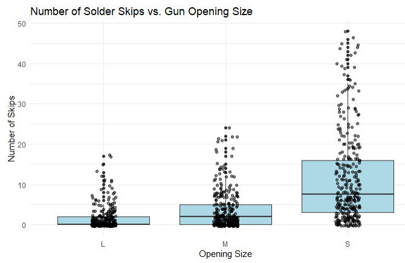

This boxplot breaks down skip counts by opening size: you can see that smaller openings yield more skips, and in every opening‑size category the skips are right‑skewed.

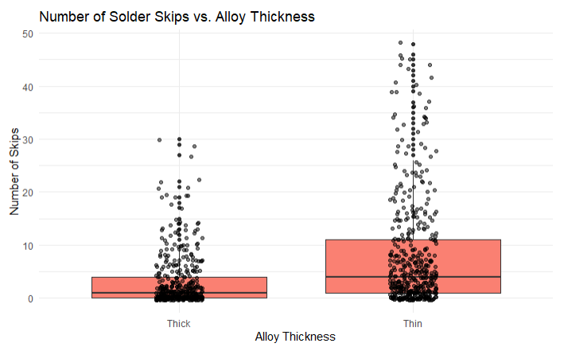

The boxplot illustrates how the number of solder skips varies with alloy thickness. Boards using thin solder show a higher median count of skips compared to those using thick solder.

## Part B)

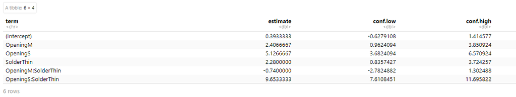

## Part C)

With 95% confidence, The true baseline number of solder skips on AT&T’s circuit boards when the soldering gun opening is large and the soldering alloy is thick is between -0.63 and 1.41.

With 95% confidence, The true main effect of the soldering gun’s opening being medium-sized lies between 0.96 and 3.85 additional solder skips.

With 95% confidence, The true main effect of the soldering gun’s opening being small-sized lies between 3.68 and 6.57 additional solder skips.

With 95% confidence, The true main effect of the soldering alloy being thing lies between 0.84 and 3.72 additional solder skips.

With 95% confidence, The true interaction effect of the soldering gun opening being medium-sized and the soldering alloy being thin lies between -2.78 and 1.30 additional solder skips.

With 95% confidence, The true interaction effect of the soldering gun opening being small-sized and the soldering alloy being thin lies between 7.61 and 11.70 additional solder skips.

## Part D)

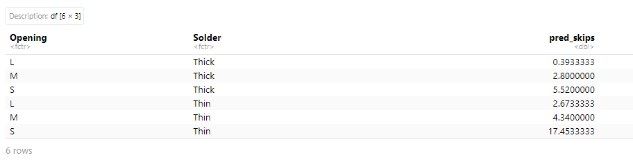

The table presents the model’s predicted skip counts for AT&T circuit boards by gun opening size and alloy thickness. The combination of a large opening and thick solder yields the fewest predicted skips, so that’s the configuration I’d recommend.

# Problem 2) Grocery store prices

## Part A)

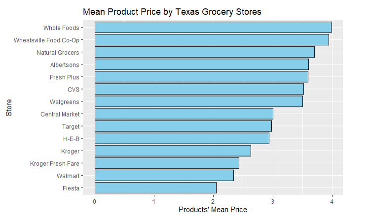

The bar chart displays each store’s average product price: Whole Foods leads with the highest mean, Wheatsville Co‑Op is a close second, and Fiesta has the lowest average prices.

## Part B)

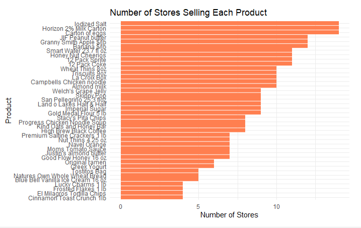

## Part C)

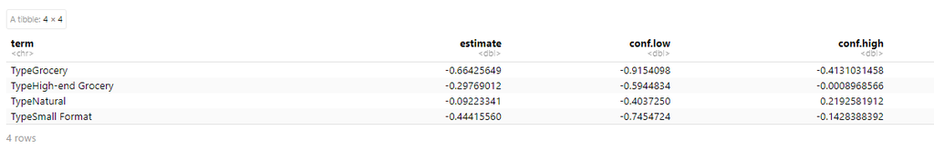

Convenience stores tend to price the same items about $0.41 to $0.92 higher than typical grocery chains like Albertsons, HEB, or Kroger.

## Part D)

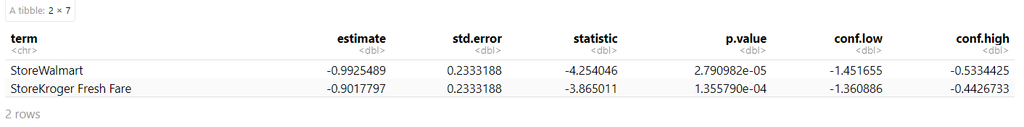

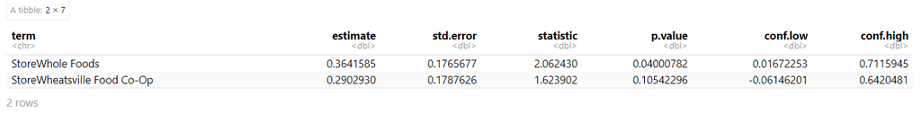

When comparing the same product, Walmart and Kroger Fresh Fare seem to charge the lowest prices. In contrast, Whole Foods and Wheatsville Food Co-Op seem to charge the highest prices when comparing the same product.

## Part E)

Cheapest store effect compared to HEB:

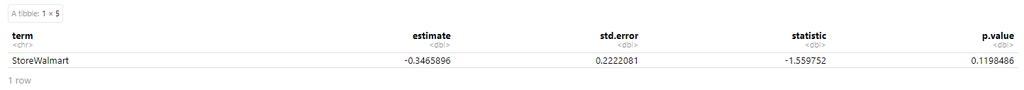

Priciest store effect compared to HEB:

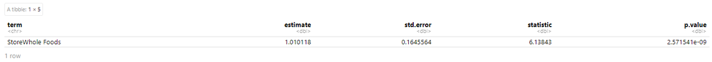

## Part F)

The negative Income10K coefficient means that higher‑income ZIP codes pay less for the same item—poorer areas end up paying more. Concretely, every $10 000 increase in median income is associated with a $0.014 decrease in price. In standardized terms, a one‑SD rise in income corresponds to a 0.03‑SD drop in expected price.

# Question 3) redlining